# README.R

yeung

2019-11-28

```r
# Jake Yeung
# Date of Creation: 2019-11-27
# File: ~/projects/CircadianRNASeq/README.R
# Test things out before moving to Rmd

library(reshape2)
library(dplyr)
```

```r
library(ggplot2)
library(hash)
library(CircadianRNASeq)
library(here())
setwd(here())
```

## Load data

```r
inf <- "data/GR_2018_Primetime_Objects.Rdata"
load(inf, v=T)
```

[output not shown]

[output cut: 194 more lines]

[output not shown]

## Plot some genes

```r
jgene <- "Dbp"
dat.sub <- subset(dat.long, gene == jgene)
```

**Expression of Dbp across tissues and time from Hogenesch data:** `#+ fig.width=4, fig.height=4, dpi=50`

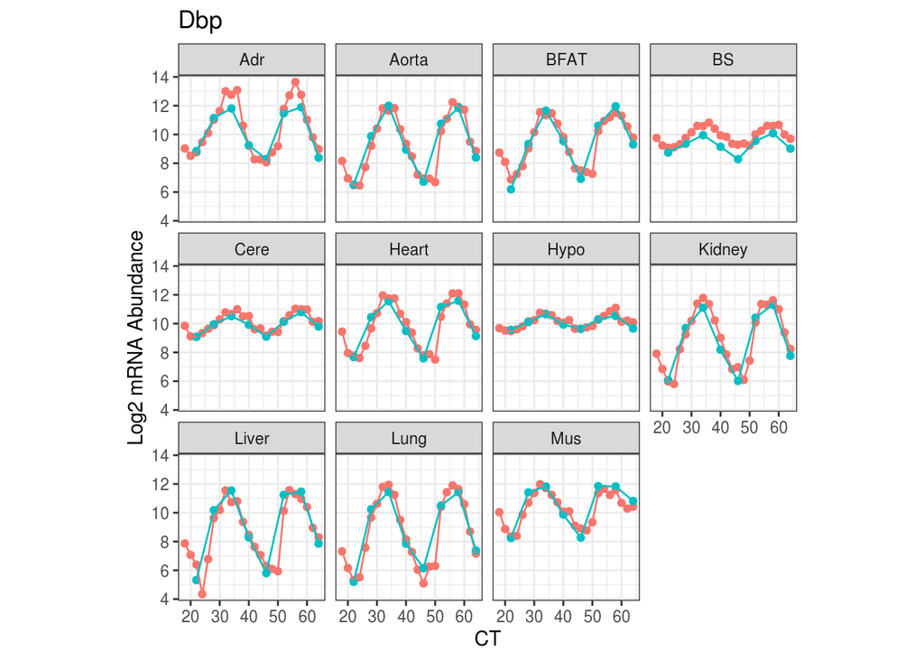

```r
PlotGeneAcrossTissues(dat.sub) + theme_bw()  + theme(aspect.ratio = 1, legend.position = "none")
```

we do model selection to identify rhythmic parameters shared or differenet across tissues **Model selection output automatically groups tissues by rhythmic parameters:** `#+ fig.width=4, fig.height=4, dpi=50`

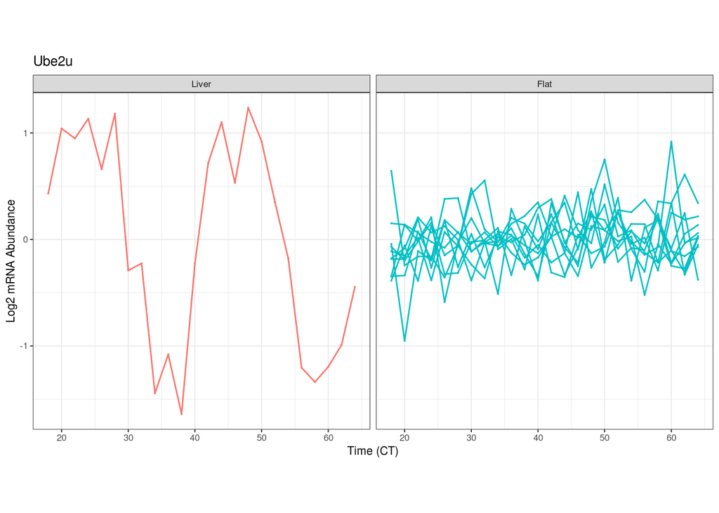

```r
jgene.byparam <- "Ube2u"
PlotGeneByRhythmicParameters(fits.long, subset(dat.long, experiment == "array"),
                                  jgene.byparam, amp.filt = 0.2, jtitle=jgene.byparam, facet.rows = 1, jcex = 8,
                                  pointsize = 0)
```

Here we show a liver-specific rhythmic gene. We plot just the microarray data for visualization purposes, although the model is fit on both microarray and RNA-seq together. ### Plot genes for WT and KO to see whether a gene is clock-controlled or clock-independent (e.g., driven by feeding rhythms)

Dbp is clock controlled, because it is flat in Bmal1 KO **WT vs KO DBP:** `#+ fig.width=4, fig.height=4, dpi=50`

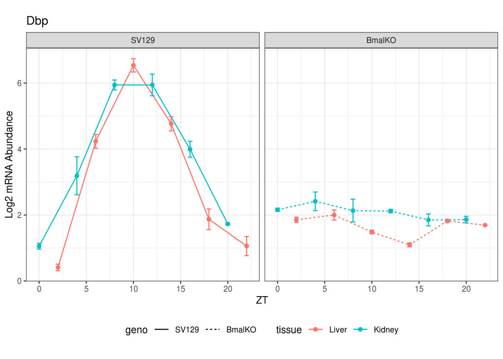

```r
PlotGeneTissuesWTKO(subset(dat.wtko, gene == jgene), jtitle = jgene, jsize = 10, single.day = TRUE)
```

The model selection for dat.wtko object is called `fits.long.filt``, here I show that Dbp is rhythmic in liver and kidney wild type, but not KO

```r
print(subset(fits.long.filt, gene == jgene))
```

```
## # A tibble: 1 x 12
## # Groups:   gene, method [1]
##   gene  model weight weight.raw param.list method n.params n.rhyth amp.avg
##   <fct> <fct>  <dbl>      <dbl> <list>     <chr>     <int>   <int>   <dbl>
## 1 Dbp   Live~  0.966      -48.7 <dbl [6]>  g=1001        1       2    2.83
## # ... with 3 more variables: phase.sd <dbl>, phase.maxdiff <dbl>,
## #   phase.avg <dbl>
```

## Complex-valued SVD

summarize tissue-wide genes using complex-valued SVD, a compact way to visualize how modules of genes oscillate across tissues

```r
svdcomponent <- 1  # look at first singular values, which captures the most variance
genes.tw <- as.character(subset(fits.long, n.rhyth >= 8)$gene)
genes.tw.wtko <- as.character(subset(fits.long.filt, model %in% c("Liver_SV129,Kidney_SV129"))$gene)

# on Hogenesch data
s.tw <- SvdOnComplex(subset(dat.complex, gene %in% genes.tw), value.var = "exprs.transformed")
# on Naef data
s.tw.wtko <- SvdOnComplex(subset(dat.freq, gene %in% genes.tw.wtko), value.var = "exprs.transformed")
eigens.tw <- GetEigens(s.tw, period = 24, comp = svdcomponent, add.arrow = TRUE, jsize = 2, label.n = 15, eigenval = TRUE, adj.mag = TRUE, constant.amp = dotsize, peak.to.trough = TRUE, label.gene = c("Dbp", "Arntl", "Per2", "Nr1d1"))
jlayout <- matrix(c(1, 2), 1, 2, byrow = TRUE)
```

**Tissue-wide SVD module:** `#+ fig.width=4, fig.height=4, dpi=50`

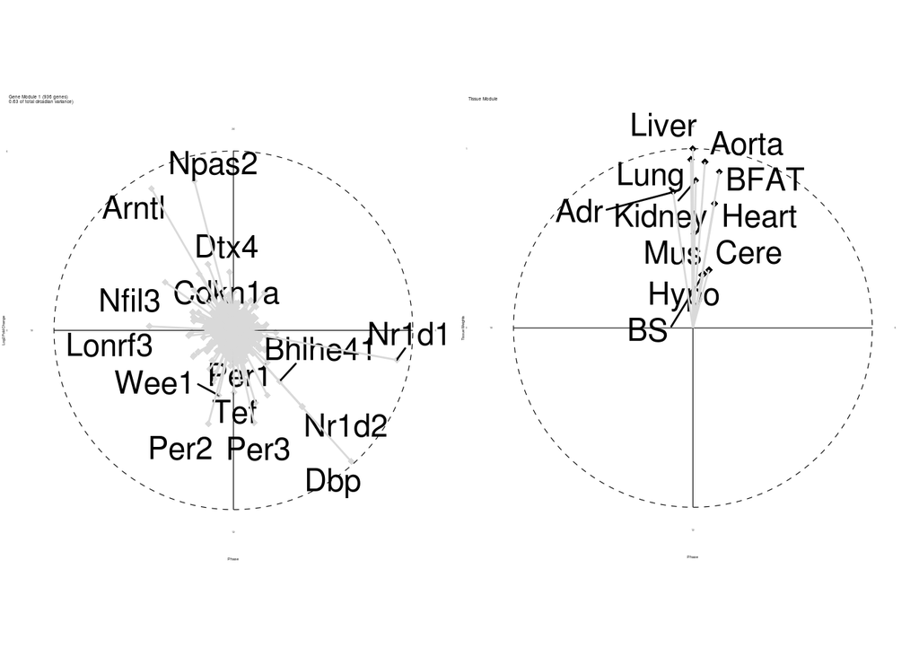

```r
multiplot(eigens.tw$u.plot, eigens.tw$v.plot, layout = jlayout)
```

The gene loadings show how the phase and amplitude relates to each other. For example, we find /Arntl/ to oscillate in phase with /Npas2/ across tissues, but antiphasic with /Dbp/.

The tissue loadings show how the oscillations of each gene relates across tissues. Here we see in this tissue-wide module that these genes oscillate in nearly all tissues, with coherent phases. However, we find the amplitudes vary (we often see brain tissues have lower amplitudes than other tissues like liver)

```r
eigens.tw.wtko <- GetEigens(s.tw.wtko, period = 24, add.arrow = TRUE, comp = svdcomponent, jsize = 2, label.n = 15, eigenval = TRUE, adj.mag = TRUE, constant.amp = dotsize, peak.to.trough = TRUE, label.gene = c("Dbp", "Arntl", "Per2", "Nr1d1"))
jlayout <- matrix(c(1, 2), 1, 2, byrow = TRUE)
```

**Tissue-wide SVD module on WT and KO data** `#+ fig.width=4, fig.height=4, dpi=50`

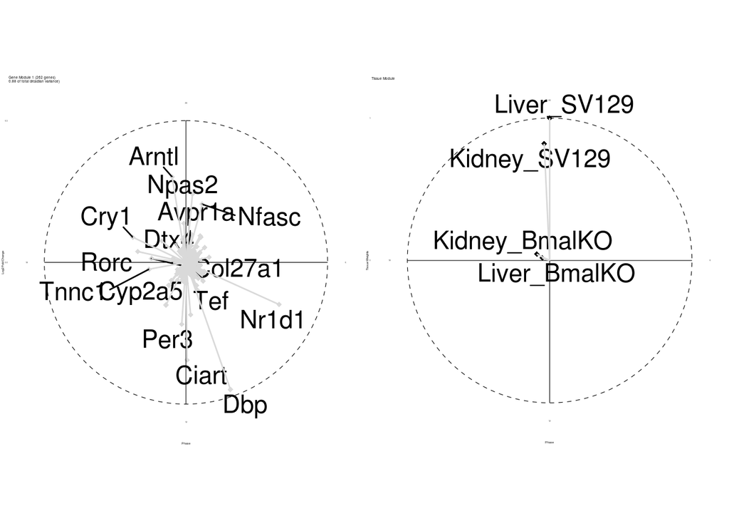

```r
multiplot(eigens.tw.wtko$u.plot, eigens.tw.wtko$v.plot, layout = jlayout)
```